# Systematic Conservation Prioritization: Exercise 2

Prioritizr demonstration - North Argentinian Dry Chaco example

Liz Law workingconservation@gmail.com

Humboldt Universität - 2018

# A more realistic example

The last problem we dealt with was quite small, less than 100 cells, and only 6 species. Most conservation problems we will encounter in the real world are much more complex, involving more species and other conservation features, larger areas, issues such as needing to include some areas (such as existing protected areas) and exclude others (that are not available for conservation), as well as considering the spatial arrangement (connectivity and clustering) of the reserve network.

We will now have a look at the NADC data on a 10km raster resolution, including additional data, and have a go at developing a more complex problem.

## Loading the packages and setting the working directory (if required)

Same as before, we need to tell R what packages to use, and where our data is - make sure you change the working directory to your own! You don’t have to do this step if you still have it all from Exercise 1.

```r
## only run if opening R anew. If still loaded from last time this is not required.

# specify packages
packList <- c("raster","rgdal","sp","devtools","prioritizr")

# check if package is installed; if not, install them
for(i in 1:length(packList)){
  if(!is.element(noquote(packList[i]),installed.packages()[,1])){
    install.packages(packList[i],dependencies = T)
  }
}
# load packages
sapply(packList, library, character.only=T)

# load lpsymphony (reinstall if you need to)
if(!is.element(noquote('lpsymphony'),installed.packages()[,1])){
 source("https://bioconductor.org/biocLite.R")
 biocLite("lpsymphony") # on one computer it asked for updating some other packages --> "n" is
                   #  a possible option
}

library(lpsymphony)

# specify working directory - dont forget to change this to your own!
wdr <-'T:/el/NADC_prioritizr/inputdata/'
```

## Loading the data

Some data layers come in as single layer rasters, others as stacks of rasters:

```r
# load the 10km raster data
forestbirds <- stack(paste0(wdr,'forestbirds10.tif'))
otherbirds <- stack(paste0(wdr,'otherbirds10.tif'))
mammals <- stack(paste0(wdr,'mammals10.tif'))
protectedareas <- raster(paste0(wdr,'protectedareas10.tif'))
areakm <- raster(paste0(wdr, 'areakm10.tif'))
intensiveareas <- raster(paste0(wdr,'intensiveareas10.tif'))
soyprofit <- raster(paste0(wdr,'soyprofit10.tif'))
smallholderdensity <- raster(paste0(wdr,'smallholderdensity10.tif'))
carbon <- raster(paste0(wdr,'carbon10.tif'))
```

Let’s check the data imported correctly, by running these lines one at a time. Pay special attention to the soyprofit data - as we will be using this for the cost, all the values need to be >0.

```r
# check import
print(forestbirds); plot(forestbirds)
print(otherbirds); plot(otherbirds)
print(mammals); plot(mammals)
print(protectedareas); plot(protectedareas)
print(intensiveareas); plot(intensiveareas)
print(soyprofit); plot(soyprofit)
print(smallholderdensity); plot(smallholderdensity)
```

What are these data exactly? That’s a great question, and one you should always ask! Check the descriptions in the Systematic Conservation Prioritization.pdf

Now, let’s find out the names of the species we are dealing with, and allocate them to the data. It’s always useful to know what species you are dealing with - for example whether they are threatened, endemic or particular to a type of habitat (e.g. wetlands), native, invasive, a keystone ecological species, of cultural significance or economic importance. We might want to treat these different types of species differently in an analysis.

```r
# load species names and examine data
speciesnames <- read.csv(paste0(wdr,'speciesnames.csv'))
print(speciesnames)
```

```
##          Type                     SpeciesName Code
## 1  ForestBird            Cacicus chrysopterus bf_1
## 2  ForestBird                Eudromia formosa bf_2
## 3  ForestBird             Melanerpes candidus bf_3
## 4  ForestBird       Spiziapteryx circumcincta bf_4
## 5  ForestBird             Sublegatus modestus bf_5
## 6      Mammal               Catagonus wagneri mm_1
## 7      Mammal       Chaetophractus vellerosus mm_2
## 8      Mammal                   Galictis cuja mm_3
## 9      Mammal              Leopardus pardalis mm_4
## 10     Mammal             Procyon cancrivorus mm_5
## 11  OtherBird Campylorhamphus trochilirostris bo_1
## 12  OtherBird            Crypturellus tataupa bo_2
## 13  OtherBird               Dryocopus schulzi bo_3
## 14  OtherBird                     Guira guira bo_4
## 15  OtherBird               Poospiza torquata bo_5
```

```r
# allocate the names to the species rasters
names(forestbirds) <- speciesnames$SpeciesName[speciesnames$Type=='ForestBird']
names(otherbirds) <- speciesnames$SpeciesName[speciesnames$Type=='OtherBird']
names(mammals) <- speciesnames$SpeciesName[speciesnames$Type=='Mammal']
```

## Gap analysis

Before we go into the prioritization, it is always useful to get an understanding of our study region and the species we are interested in. Here we do this with a simple ‘gap analysis’ - an assessment of how much of each species is already in the reserve network.

First, we find out how much area is in the reserve network. For this, we will simply assume that cells with more than 50% of their area in the reserve network are ‘protected’, and less than that ‘not protected’. Second, we find out how much of each species there could be across the study area. Third, we find out how much of each species is represented within the current reserve network.

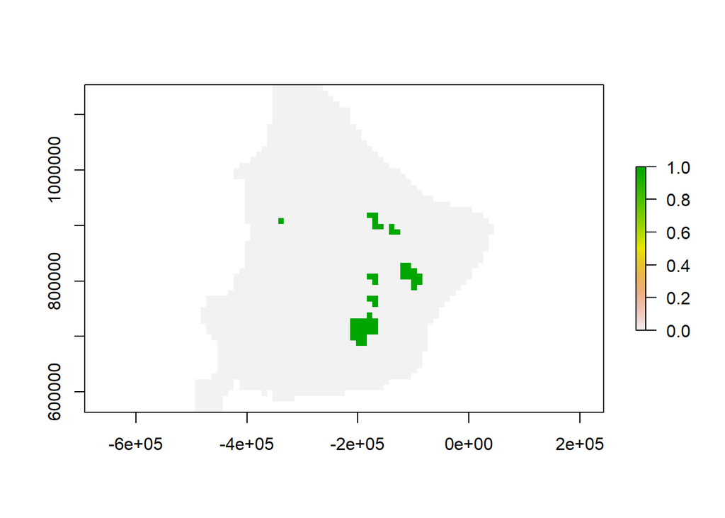

```r
## Gap analysis
# how much area already in reserves?
# protectedareas>50 gives us a binary raster (true/false) that we need to times by the planning unit area
reserved <- protectedareas>=50
plot(reserved)
```

```r
reservearea <- cellStats(areakm*reserved, sum)
totalarea <- cellStats(areakm, sum)
reservearea/totalarea*100
```

```
## [1] 2.755501
```

```r
# species totals
speciestotals <- c( round(cellStats(forestbirds, sum)),
                    round(cellStats(otherbirds, sum)),
                    round(cellStats(mammals, sum)))
speciesprotected <- c( round(cellStats(forestbirds*reserved, sum)),
                       round(cellStats(otherbirds*reserved, sum)),
                       round(cellStats(mammals*reserved, sum)))
speciesnames <- c( names(forestbirds),
                   names(otherbirds),
                   names(mammals))
speciesprotected <- as.data.frame(cbind(
                           speciesnames,
                           speciestotals,
                           speciesprotected,
                           percentprotected = round(speciesprotected/speciestotals*100, 2)))
rownames(speciesprotected) <- NULL # this just cleans up our dataframe
print(speciesprotected)
```

```
##                       speciesnames speciestotals speciesprotected
## 1             Cacicus.chrysopterus        902625            21855
## 2                 Eudromia.formosa        838826            28948
## 3              Melanerpes.candidus       1216260            38540
## 4        Spiziapteryx.circumcincta       1302710            42460
## 5              Sublegatus.modestus        796493            27613
## 6  Campylorhamphus.trochilirostris        566115            19374
## 7             Crypturellus.tataupa       1155109            37907
## 8                Dryocopus.schulzi        342960            22494
## 9                      Guira.guira        305868             9530
## 10               Poospiza.torquata        269285            12647
## 11               Catagonus.wagneri        147216             6966
## 12       Chaetophractus.vellerosus        819688            24098
## 13                   Galictis.cuja        451648            21288
## 14              Leopardus.pardalis        719782            19452
```

[output cut: 17 more lines]

*What proportion of the area is already protected?* *Which species really need more protection?*

## Prioritizr examples

### Lock in, lock out

We saw just the basic prioritizr example using the simplified data before. So let’s launch straight in to including some more complexities - locking in and locking out certain cells.

For example, we might want to lock in cells that already have existing protected areas.  
*Why might we do this? What are the implications of this?*

We might also want to lock out cells that are already intensive agriculture.  
*Why might this be useful? What are the implications of this?*

Note, one of the things we need to be careful with here is feasibility - we can’t tell prioritizr to lock in and lock out the same cells. This is infeasible (i.e. impossible to do). In this case we are lucky: the lock in and lock out cells that we use are not overlapping. If they did overlap, fortunately Prioritizr will detect this and will give an informative error message.

```r
# set up the problem
p0 <- problem(soyprofit, stack(forestbirds, otherbirds, mammals)) %>%
  add_min_set_objective() %>%
  add_relative_targets(0.17) %>%
  add_locked_in_constraints(protectedareas>50) %>%
  add_locked_out_constraints(intensiveareas>50) %>%
  add_binary_decisions()  %>%
  add_lpsymphony_solver(gap=0.1)

s0 <- solve(p0)
```

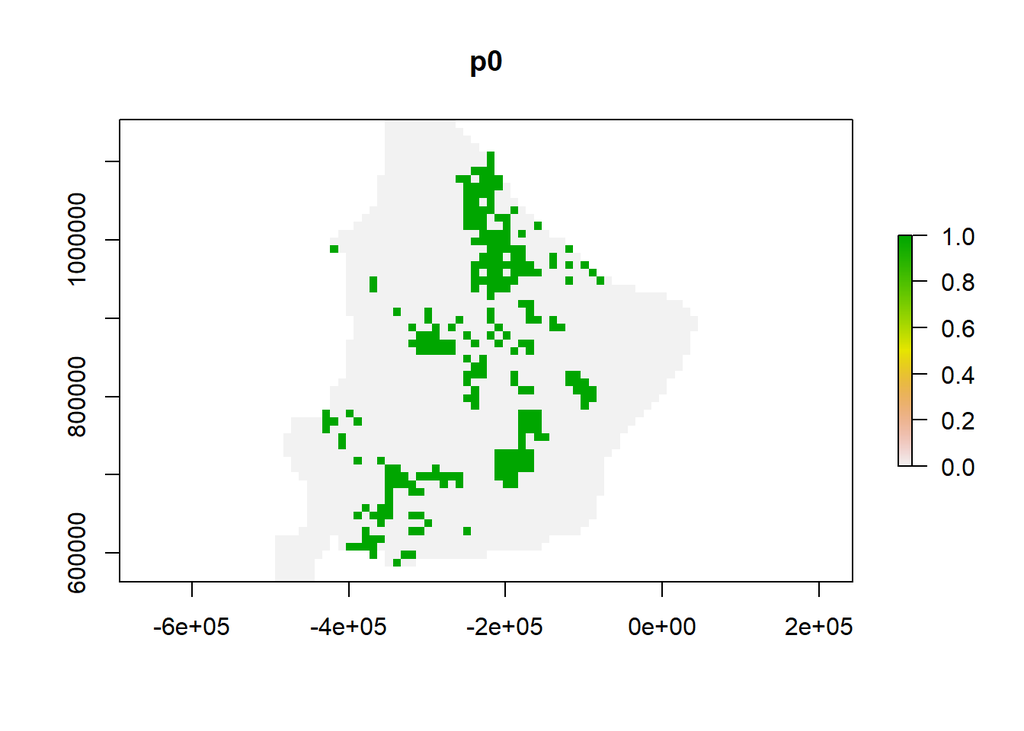

```r
# some post-processing options:
plot(s0, main = "p0")
```

```r
cellStats(s0*soyprofit, sum)    # cost in lost soy profit
```

```
## [1] 3637495
```

```r
cellStats(s0*areakm, sum)     # selected area
```

```
## [1] 24094
```

```r
cellStats(s0*forestbirds[[1]], sum) # amount of Cacicus chrysopterus selected (forest bird 1)
```

```
## [1] 153600
```

### Adding connectivity

So far we have been dealing with linear problems, in which the selection of one cell does not influence the benefit values of another. But there are many reasons why we might want certain spatial arrangements in our protected area networks. You might remember the SLOSS debate from the last lecture, for instance, which deals mainly with species requirements. But also, fewer, larger reserves can make it easier/cheaper to manage (i.e. there are ‘economies of scale’), and clearer for the general public to know where is protected and where not.

Including connectivity into conservation problems makes them non-linear, because the selection of one cell can influence the benefit values of another. However, one of the major advancements programmed into Prioritizr is the linearization of these non-linear problems. First described (for conservation problems) in [Beyer et al (2016)](https://doi.org/10.1016/j.ecolmodel.2016.02.005), this mathematical trick allows us to solve these problems using linear/integer programming methods.

```
Beyer, H. L., Dujardin, Y., Watts, M. E., & Possingham, H. P. (2016). Solving conservation planning problems with integer linear programming. Ecological Modelling, 328, 14-22.
```

In Prioritizr there are several different methods to include connectivity concerns. Some work by adding ‘constraints’ such as requiring selected cells to have a certain number of selected neighbours. Other options work via adding a penalty to the cost / minimization objective. We will use one version of the latter: the `add_boundary_penalties()` option.

This option is the same as the one implemented in one of the other conservation planning software, Marxan. For every exposed boundary of a solution, it adds a penalty, relative to the length of this exposed boundary.

To implement this, we will first create the boundary matrix, using `boundary_matrix()`. This will create a *sparse matrix* of data which represents the boundary lengths between each cell pair. If we don’t do this ourselves, Prioritizr will create one automatically from the cost/pu data, but this way gives us a little more control, and if we are doing several different analyses using the same data it saves us from having to re-make this data every time. A *sparse matrix* is just a way of efficiently representing data with a lot of zeros.

But first, here is an example of how this boundary length matrix works:

```r
# lets create a little test raster
test <- crop(soyprofit, extent(-284816.9, -254816.9, 1123636, 1153636))
test
```

```
## class       : RasterLayer
## dimensions  : 3, 3, 9  (nrow, ncol, ncell)
## resolution  : 10000, 10000  (x, y)
## extent      : -284816.9, -254816.9, 1123636, 1153636  (xmin, xmax, ymin, ymax)
## coord. ref. : +proj=aea +lat_1=-5 +lat_2=-42 +lat_0=-32 +lon_0=-60 +x_0=0 +y_0=0 +ellps=aust_SA +units=m +no_defs
## data source : in memory
## names       : soyprofit10
## values      : 757.612, 20636.06  (min, max)
```

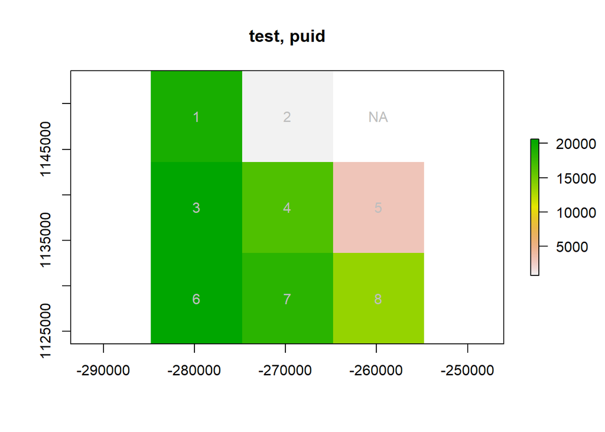

```r
# create labels to plot
puidtest <- c(1,2,'NA',3,4,5,6,7,8)
# identify their locations
xytest <- xyFromCell(test, 1:9)
# plot with labels
plot(test, main = "test, puid")
text(xytest[,1], xytest[,2], puidtest, col='gray')
```

```r
# then run the boundary matrix
blmtest <- boundary_matrix(test)
print(blmtest)
```

```
## 9 x 9 sparse Matrix of class "dsCMatrix"
##
##  [1,] 20000 10000 . 10000     .     .     .     .     .
##  [2,] 10000 20000 .     . 10000     .     .     .     .
##  [3,]     .     . .     .     .     .     .     .     .
##  [4,] 10000     . . 10000 10000     . 10000     .     .
##  [5,]     . 10000 . 10000     . 10000     . 10000     .
##  [6,]     .     . .     . 10000 20000     .     . 10000
##  [7,]     .     . . 10000     .     . 20000 10000     .
##  [8,]     .     . .     . 10000     . 10000 10000 10000
##  [9,]     .     . .     .     . 10000     . 10000 20000
```

```r
# what exactly does this mean? Let's look at the help file, under 'details'
?boundary_matrix
```

```
## starting httpd help server ... done
```

This clarifies for us that “Cells on the off-diagonal indicate the length of the shared boundary between two different planning units. Cells on the diagonal indicate length of a given planning unit’s edges that have no neighbors.” *Check that this makes sense to you given the data we entered above, and the matrix that resulted.*

Let’s create the boundary matrix for our NADC problem. We can just add this additional penalty to the existing problem, to create the new problem ‘p1’.

```r
# create boundary matrix
blm <- boundary_matrix(soyprofit)

# add this into the problem from before
p1 <- p0 %>%
      add_boundary_penalties(penalty = 0.05, edge_factor = 0.5, data = blm)

s1 <- solve(p1)
```

Some post processing options, the same as last time:

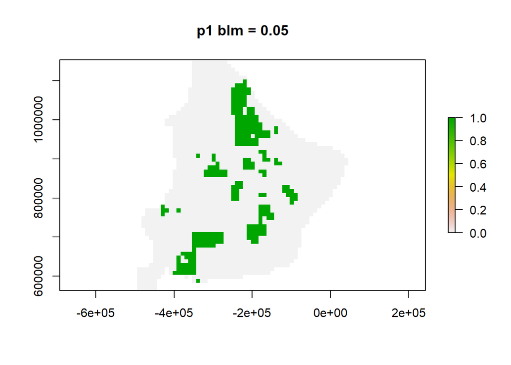

```r
plot(s1, main = "p1 blm = 0.05")
```

```r
cellStats(s1*soyprofit, sum)    # cost in lost soy profit
```

```
## [1] 3674978
```

```r
cellStats(s1*areakm, sum)     # area in km2
```

```
## [1] 24552
```

```r
cellStats(s1*forestbirds[[1]], sum) # amount of Cacicus chrysopterus selected (forest bird 1)
```

```
## [1] 158430
```

But we might also want to compare the previous solution against this one as well. We can do that by though a little addition trick.

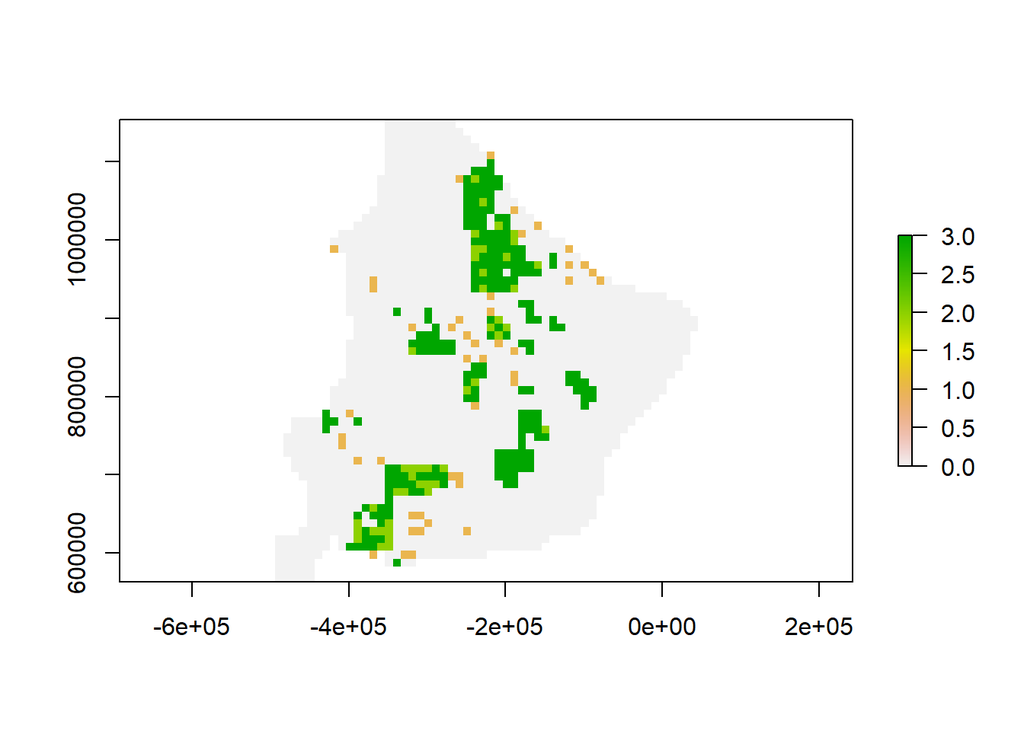

```r
# plot the selections, using the key below

# Key:
# 0 = not selected
# 1 = selected in s0 only
# 2 = selected in s1 only
# 3 = selected in both

sf <- s0 + (s1 * 2)

plot(sf)
```

Note, when doing raster math, R will automatically undersand so long as you specify the raster first (i.e s1*2 not 2*s1).

The above code allows us to visually see the overlap - but we might also want to calculate the areas themselves:

```r
# calculate the areas identified for conservation in the category 1 above
cellStats((sf==1)*areakm, sum)
```

```
## [1] 3719
```

Congratulations - now we should have all the basics sorted to be able to develop some scenarios to explore the issue of prioritization more deeply.